# 2026_09_01 Decomposition, lecture notes

- Show All Code
- Hide All Code
- View Source

Published

August 31, 2026

**Hide the code**

```r
##############################################################################
#############       Lab Practice 1: Decomposition Methods     ################
##############################################################################
```

# Carga de librerías

**Hide the code**

```r
# Load libraries
library(fpp2)
library(tidyverse)
library(readxl)
```

En clase comentaremos **como instalar librerías de R**.

# Lectura de datos

En clase comentaremos **como elegir el directorio de trabajo*.

**Hide the code**

```r
# Line 13
# Load dataset -------------------------------------------------------------------------------------------------------
fdata <- read.table("Unemployment.dat", sep = ",", header = TRUE)
```

**Ejercicio:** prueba a ejecutar esta segunda versión:

**Hide the code**

```r
fdata <- read.table("Unemployment.dat", sep = ",", header = TRUE)
```

## Otros formatos (e.g. Excel)

**Hide the code**

```r
fdata2 <- read_excel("Unemployment.xlsx")
```

Para visualizar un objeto en R podemos simplemente usar su nombre. ¡Pero con objetos grandes no es una buena idea!

**Hide the code**

```r
# Line 18
# Visualize data
fdata
```

Es mejor usar `head` y `tail`

**Hide the code**

```r
head(fdata)
```

```
        DATE   TOTAL
1 01/01/2010 4048493
2 01/02/2010 4130625
3 01/03/2010 4166613
4 01/04/2010 4142425
5 01/05/2010 4066202
6 01/06/2010 3982368
```

**Hide the code**

```r
tail(fdata, 10)
```

```
          DATE   TOTAL
147 01/03/2022 3108763
148 01/04/2022 3022503
149 01/05/2022 2922991
150 01/06/2022 2880582
151 01/07/2022 2883812
152 01/08/2022 2924240
153 01/09/2022 2941919
154 01/10/2022 2914892
155 01/11/2022 2881380
156 01/12/2022 2837653
```

Las funciones `glimpse` y `str` proporcionan información sobre la estructura de datos.

**Hide the code**

```r
glimpse(fdata)
```

```
Rows: 156
Columns: 2
$ DATE  <chr> "01/01/2010", "01/02/2010", "01/03/2010", "01/04/2010", "01/05/2…
$ TOTAL <int> 4048493, 4130625, 4166613, 4142425, 4066202, 3982368, 3908578, 3…
```

¿Qué tipo de objeto es `fdata`?

**Hide the code**

```r
str(fdata)
```

```
'data.frame':   156 obs. of  2 variables:
 $ DATE : chr  "01/01/2010" "01/02/2010" "01/03/2010" "01/04/2010" ...
 $ TOTAL: int  4048493 4130625 4166613 4142425 4066202 3982368 3908578 3969661 4017763 4085976 ...
```

Es un data.frame, una estructura tabular heterogénea básica en R. Para aprender un poco más puede usar el siguiente **Tutorial sobre R (nivel básico)**:

[R Tutorial – An Introduction for Beginners](https://www.evamariakiss.de/tutorial/r/)

# Exploratory Data Analysis for Time Series

## Frecuencia de la serie temporal

**Esta es la pregunta más importante que debes hacerte al principio del trabajo con una serie temporal:**

**Hide the code**

```r
# Line 22
# What is the frequency of observation for this data.
# Is this data yearly? (or quarterly, monthly, weekly, daily,...)


# Check for missing dates
fdata$DATE <- as.Date(fdata$DATE, format = "%d/%m/%Y")
```

**Notas:**

- `<-` es la asignación en R (atajos de teclado en RStudio).
- `$` permite acceder por nombre a una columna de un data.frame

Siempre es conveniente asegurarse de ordenar la serie temporal por fecha

**Hide the code**

```r
# Line 28
fdata <- fdata %>% arrange(DATE)
# same as: fdata <- arrange(fdata,DATE)
```

El operador `%>%` es un `pipe`.

¿Qué ha cambiado con `as.Date`?

**Hide the code**

```r
glimpse(fdata)
```

```
Rows: 156
Columns: 2
$ DATE  <date> 2010-01-01, 2010-02-01, 2010-03-01, 2010-04-01, 2010-05-01, 201…
$ TOTAL <int> 4048493, 4130625, 4166613, 4142425, 4066202, 3982368, 3908578, 3…
```

## Dos posibles formas de tener datos ausentes en series temporales

### huecos temporales

Puede haber fechas que faltan en la serie. Cuidado: es fácil que pasen inadvertiddos.

**Hide the code**

```r
# Line 32
# How do we know if there are time gaps in the data?
range(fdata$DATE)
```

```
[1] "2010-01-01" "2022-12-01"
```

**Hide the code**

```r
min(fdata$DATE)
```

```
[1] "2010-01-01"
```

**Hide the code**

```r
max(fdata$DATE)
```

```
[1] "2022-12-01"
```

**Hide the code**

```r
# Line 37
# Therefore we can create a complete sequence of months with the same range and
# compare it to the dates in our data.
date_range <- seq.Date(min(fdata$DATE), max(fdata$DATE), by = "months")

head(date_range)
```

```
[1] "2010-01-01" "2010-02-01" "2010-03-01" "2010-04-01" "2010-05-01"
[6] "2010-06-01"
```

**Hide the code**

```r
tail(date_range)
```

```
[1] "2022-07-01" "2022-08-01" "2022-09-01" "2022-10-01" "2022-11-01"
[6] "2022-12-01"
```

**Sugerencia:** prueba a cambiar `by = "months"` por `by = "weeks"` (y luego asegúrate de deshacer el cambio)

**Pregunta:** ¿qué tipo de objeto es `date_range`?

**Hide the code**

```r
# Line 44
# Now we do the comparison
date_range[!date_range %in% fdata$DATE]
```

```
Date of length 0
```

Si el resultado es `Date of length 0` es que no hay huecos temporales. Si los hay, aparecerán.

**Ejercicio:**

1. Crea una copia de `Unemployment.dat` en la misma carpeta, llámala `Unemployment_gaps.dat`
2. Elimina la tercera fecha de ese fichero usando un *editor de texto*.
3. Ejecuta todo el código anterior cambiando de fichero. *Indicación:* usa el menú `Code/ Re-run Previous`.
4. Observa el resultado del último comando. Debe ser `[1] "2010-03-01"`
5. Deshaz los cambios y vuelve a ejecutar todo el código. *Indicación:* aprende a comentar y descomentar líneas de manera eficiente.

## Curso relámpago de selección en R:

Vamos a usar la **evaluación parcial** de RStudio para entender el comando.

**Hide the code**

```r
date_range[!date_range %in% fdata$DATE]
```

Pero para eso necesitamos entender cómo se selecciona elementos de un vector en R (en este caso, el vector `date_range`).

**Hide the code**

```r
# genero un vector de 15 números del 1 al 10 en orden aleatorio (pero reproducible)
set.seed(2025)
a <- sample(1:10, 15, replace = TRUE)
a
```

```
 [1]  4 10  1  7 10  1  4  7  5  7  5  1  9  6  8
```

Selecciono los tres primeros

**Hide the code**

```r
a[c(1, 2, 3)]
```

```
[1]  4 10  1
```

**Hide the code**

```r
# es lo mismo que
a[1:3]
```

```
[1]  4 10  1
```

Selecciono posiciones no consecutivas

**Hide the code**

```r
a[c(4, 2, 6)]
```

```
[1]  7 10  1
```

Condicionales y vectores booleanos:

**Hide the code**

```r
a < 6
```

```
 [1]  TRUE FALSE  TRUE FALSE FALSE  TRUE  TRUE FALSE  TRUE FALSE  TRUE  TRUE
[13] FALSE FALSE FALSE
```

y uso esto como *selector*

**Hide the code**

```r
a[a < 6]
```

```
[1] 4 1 1 4 5 5 1
```

**Pregunta:** ¿qué hace la función `which`? Más en general, ¿cómo obtengo ayuda en R?

## Datos ausentes clásicos

Es decir, los NA habituales en una variable no temporal.

**Hide the code**

```r
# Line 46
sum(is.na(fdata$TOTAL))
```

```
[1] 0
```

**Ejercicio:** usa la evaluación parcial de nuevo para entender lo que hemos hecho aquí

Más adelante veremos en detalle cómo tratar el problema de los datos ausentes.

# Time series `ts` object

- Lectura recomendada:  
  *Hands-On Time Series Analysis with R* de R. Krispin Krispin (2019)
- Otra lectura sugerida (2017):  
  [Time Series Analysis in R Part 1: The Time Series Object](https://datascienceplus.com/time-series-analysis-in-r-part-1-the-time-series-object/)  
  [Time Series Analysis in R Part 2: Time Series Transformations](https://datascienceplus.com/time-series-analysis-in-r-part-2-time-series-transformations/)

**Hide the code**

```r
# Line 48
# Convert to time series object
# start -> year
# frequency = 12 -> monthly data
# frequency = 4 -> quarterly data
y <- ts(fdata$TOTAL, start = c(2010,1), frequency = 12)
```

¿Qué aspecto tiene `y`?

**Hide the code**

```r
head(y, 20)
```

```
         Jan     Feb     Mar     Apr     May     Jun     Jul     Aug     Sep
2010 4048493 4130625 4166613 4142425 4066202 3982368 3908578 3969661 4017763
2011 4231003 4299263 4333669 4269360 4189659 4121801 4079742 4130927
         Oct     Nov     Dec
2010 4085976 4110294 4100073
2011
```

**Nota:** las funciones `head` y `tail` funcionan bien con objetos `ts` y a menudo son la forma más sencilla de *dividir* una serie temporal (por ejemplo, para hacer un split entre train y test).

# Time Series Graphics

El gráfico básico es un `time plot`. Lo podemos obtener con `autoplot`

**Hide the code**

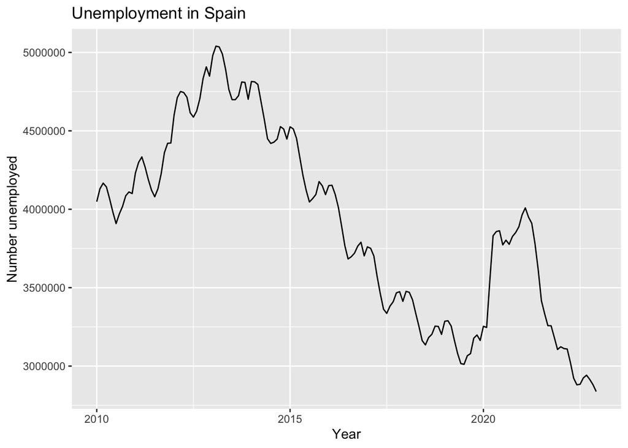

```r
# Line 54
#Plot time series:
autoplot(y) +
  ggtitle("Unemployment in Spain") +
  xlab("Year") + ylab("Number unemployed")
```

o con una función más básica como `plot.ts`

**Hide the code**

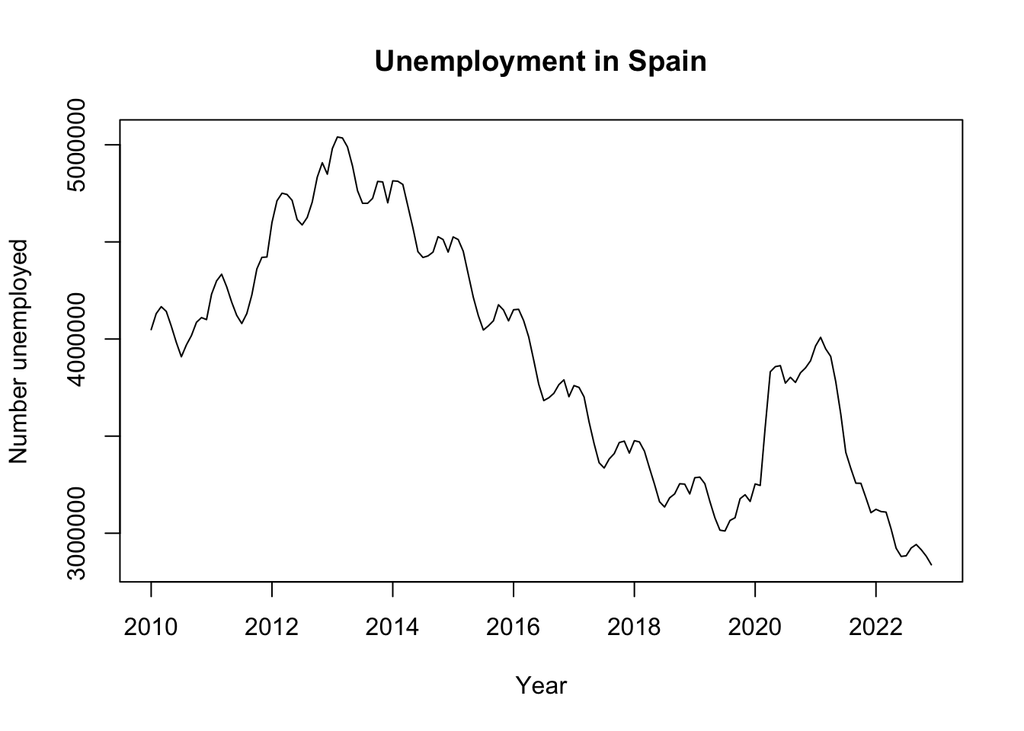

```r
# Line 60
# or:
plot.ts(y,
        main="Unemployment in Spain",
        xlab="Year",
        ylab="Number unemployed")
```

# La función `window` para seleccionar en series temporales

La función `window` permite extraer una parte de la serie temporal. Podemos indicar comienzo y final de la selección, pero a menudo usaremos `window` para dividir la serie en algo como:

- `y_a` es *datos hasta 2019 inclusive*,
- `y_b` es *datos desde 2020 inclusive.

Esto se puede hacer con `window` así:

**Hide the code**

```r
# Line 65
# Select time series time frame
y_a <- window(y, end = c(2019, 12))
y_b <- window(y, start = c(2020,1))
```

Comprobemos:

**Hide the code**

```r
tail(y_a)
```

```
         Jul     Aug     Sep     Oct     Nov     Dec
2019 3011433 3065804 3079711 3177659 3198184 3163605
```

**Hide the code**

```r
head(y_b)
```

```
         Jan     Feb     Mar     Apr     May     Jun
2020 3253853 3246047 3548312 3831203 3857776 3862883
```

Vamos a pintarlas juntas para visualizar esta división:

**Hide the code**

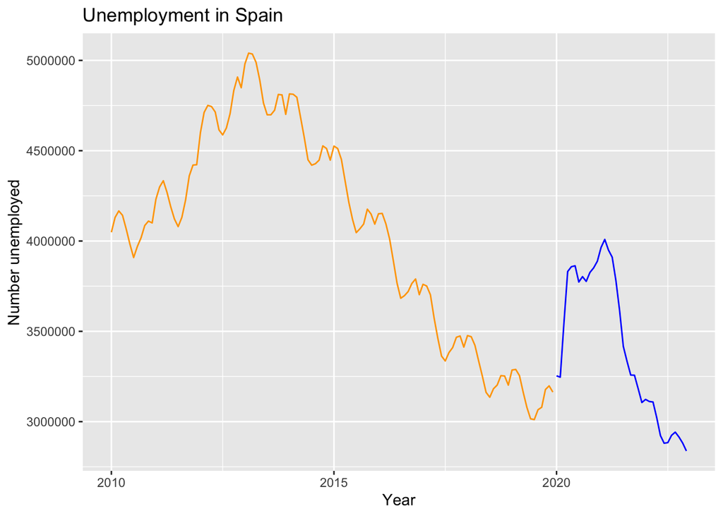

```r
# Line 71
#Plot time series
autoplot(y_a, color="orange") +
  autolayer(y_b, color = "blue") +
  ggtitle("Unemployment in Spain") +
  xlab("Year") + ylab("Number unemployed")
```

También se puede usar `window` con `start` y `end` a la vez.

**Hide the code**

```r
# or:
y_c <- window(y, start = c(2015, 1), end = c(2017, 12))
y_c
```

```
         Jan     Feb     Mar     Apr     May     Jun     Jul     Aug     Sep
2015 4525691 4512153 4451939 4333016 4215031 4120304 4046276 4067955 4094042
2016 4150755 4152986 4094770 4011171 3891403 3767054 3683061 3697496 3720297
2017 3760231 3750876 3702317 3573036 3461128 3362811 3335924 3382324 3410182
         Oct     Nov     Dec
2015 4176369 4149298 4093508
2016 3764982 3789823 3702974
2017 3467026 3474281 3412781
```

**Ejercicio:**

- examina `y_c`. ¿Puedes añadirla al gráfico anterior?
- **Opcional:** ¿qué pasa si usas esta versión? `y_c <- window(y, start = c(2015, 1), end = c(2017, 12), frequency=4)`

**Hide the code**

```r
autoplot(y_a, color="orange") +
  autolayer(y_b, color = "blue") +
  autolayer(y_c, color = "red") +
  ggtitle("Unemployment in Spain") +
  xlab("Year") + ylab("Number unemployed")
```

[output not shown]

# Decomposition methods

La función `decompose` permite obtener descomposiciones clásicas.

**Hide the code**

```r
# Line 77
#################################################################################
# Decomposition methods
#################################################################################

## Classical additive decomposition
y_dec_add <- decompose(y, type="additive")
```

**Pregunta:**

- ¿qué clase de objeto es `y_dec_add`?
- consulta la ayuda de `decompose` para ver cómo puedes extraer las componentes a partir de `y_dec_add`.
- Usa `head` para explorar el comienzo de la serie de tendencia. ¿Qué ocurre y por qué?

La descomposición puede representarse gráficamente con `autoplot`:

**Hide the code**

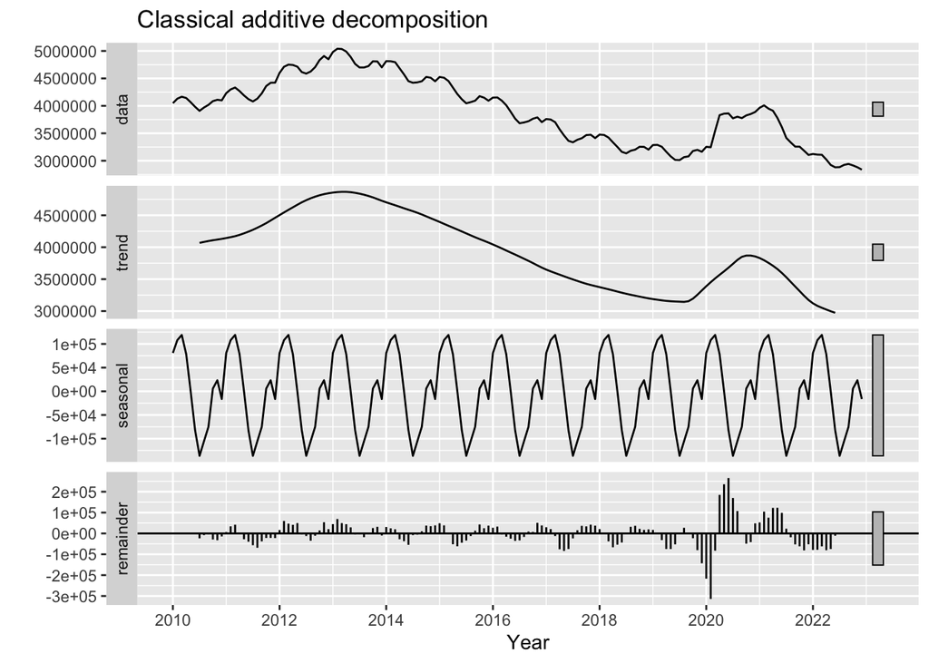

```r
# Line 84
autoplot(y_dec_add) + xlab("Year") +
  ggtitle("Classical additive decomposition")
```

En clase veremos el significado de esos rectángulos grises. La descomposición multiplicativa es similar.

**Hide the code**

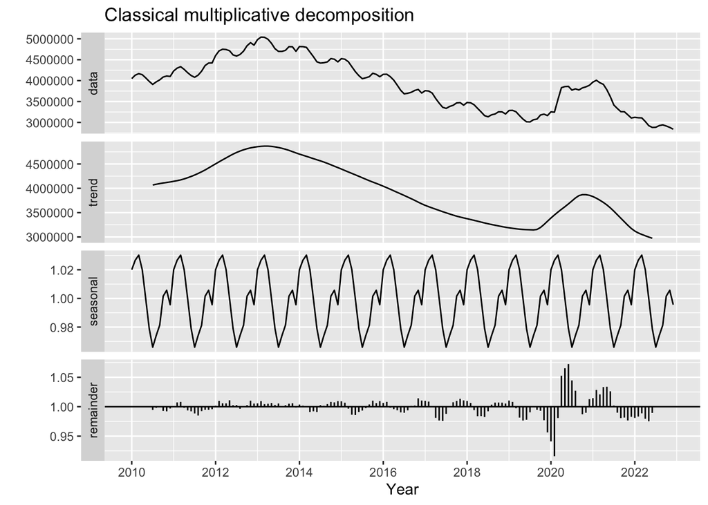

```r
# Line 88
## Classical Multiplicative decomposition
y_dec_mult <- decompose(y, type="multiplicative")
autoplot(y_dec_mult) + xlab("Year") +
  ggtitle("Classical multiplicative decomposition")
```

Para obtener otro tipo de descomposiciones debemos cargar librerías adicionales. Por ejemplo, `seas` de la librería `seasonal`

**Hide the code**

```r
# Line 94
## SEATS
library(seasonal)
```

**Hide the code**

```r
y_dec_seas <- seas(y)
```

De nuevo con autoplot podemos visualizar esta descomposición.

**Hide the code**

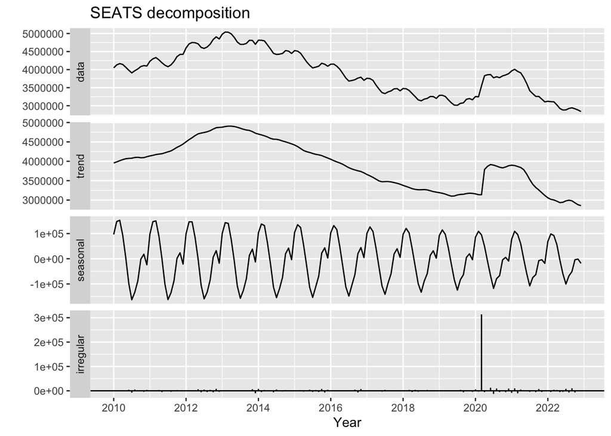

```r
# Line 96
autoplot(y_dec_seas) + xlab("Year") +
  ggtitle("SEATS decomposition")
```

El resto del código compara las distintas descomposiciones gráficamente.

**Hide the code**

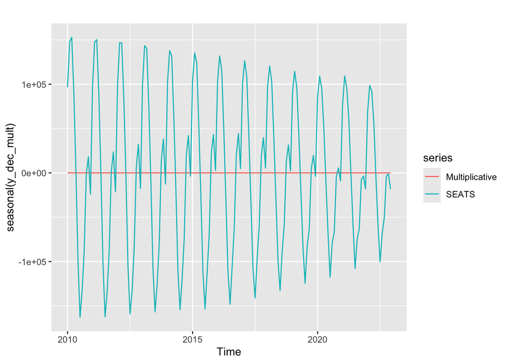

```r
# Use seasonal(), trendcycle() and remainder() functions to extract the individual components.
# Use seasadj() to compute the seasonally adjusted time series.

#Compare seasonal components
autoplot(seasonal(y_dec_mult), series = "Multiplicative") +
  forecast::autolayer(seasonal(y_dec_seas), series = "SEATS")
```

**Hide the code**

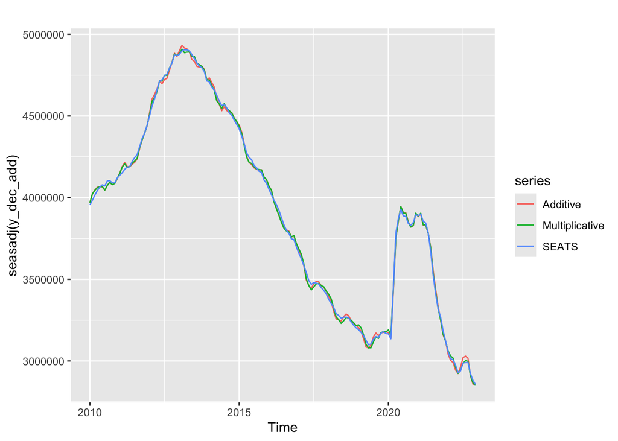

```r
#Compare seasonal adjustment components (i.e. subtracting the seasonal component from the raw series)
autoplot(seasadj(y_dec_add), series = "Additive") +
  forecast::autolayer(seasadj(y_dec_mult), series = "Multiplicative") +
  forecast::autolayer(seasadj(y_dec_seas),series = "SEATS")
```

## References

Hyndman, R. J., & Athanasopoulos, G. (2021). *Forecasting: Principles and practice, 3rd edition*. OTexts. Retrieved from https://otexts.com/fpp3/

Krispin, R. (2019). *Hands-on time series analysis with r: Perform time series analysis and forecasting using r*. Packt Publishing Ltd. Retrieved from https://github.com/PacktPublishing/Hands-On-Time-Series-Analysis-with-R